# 7. Factor Analysis

## *Factor Analysis (FA)*

*Data with large number of measured variables have the possibility of having some variables to “overlap” due to its inherent dependency. Factor Analysis (FA) is an exploratory data analysis method used to search influential underlying factors or latent variables from a set of observed variables. It is a method for investigating whether a number of variables of interest Y1, Y2,……., Yl, are linearly related to a smaller number of unobservable factors F1, F2,..……, Fk.*

*It helps in data interpretations by reducing the number of variables. It extracts maximum common variance from all variables and puts them into a common score.*

*Factor analysis is widely utilized in market research, advertising, psychology, finance, and operation research. Market researchers use factor analysis to identify price-sensitive customers, identify brand features that influence consumer choice, and helps in understanding channel selection criteria for the distribution channel.*

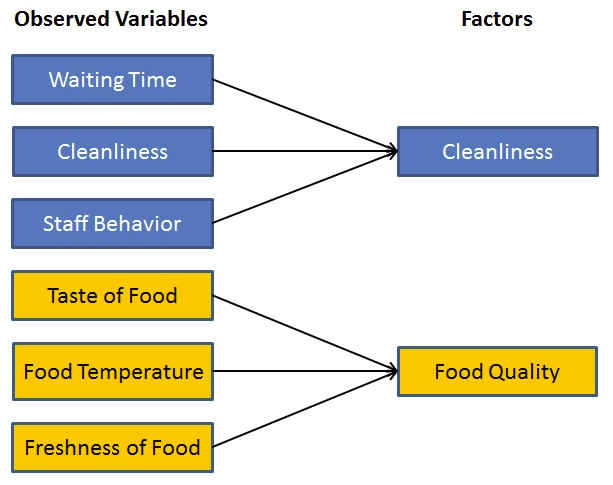

*Assumptions:*

- *There are no outliers in data.*
- *Sample size should be greater than the factor.*
- *There should not be perfect multicollinearity.*
- *There should not be homoscedasticity between the variables.*

*Types of Factor Analysis*

1. *Exploratory Factor Analysis:*

*It is the most popular factor analysis approach among social and management researchers. Its basic assumption is that any observed variable is directly associated with any factor.*

*When you are not sure, how many latent variables exists and what are their nature - we conduct EFA.*

1. *Confirmatory Factor Analysis (CFA):*

*Its basic assumption is that each factor is associated with a particular set of observed variables. CFA confirms what is expected on the basic.*

*When you have some guess or model for your latent factor and you want to check whether your model is correct ot not - we conduct CFA.*

*What is a factor?*

*A factor is a latent variable which describes the association among the number of observed variables. The maximum number of factors are equal to a number of observed variables. Every factor explains a certain variance in observed variables. The factors with the lowest amount of variance were dropped. Factors are also known as latent variables or hidden variables or unobserved variables or Hypothetical variables.*

*What are the factor loadings?*

*The factor loading is a matrix which shows the relationship of each variable to the underlying factor. It shows the correlation coefficient for observed variable and factor. It shows the variance explained by the observed variables.*

*What is Eigenvalues?*

*Eigenvalues represent variance explained each factor from the total variance. It is also known as characteristic roots.*

*Adequacy Test*

*Before we perform factor analysis, we need to evaluate the “factorability” of our dataset. Factorability means “can we find the factors in the dataset?”. There are two methods to check the factorability:*

1. *Bartlett’s Test*
2. *Kaiser-Meyer-Olkin Test*

*Bartlett’s Test*

*Bartlett’s test of sphericity checks whether or not the observed variables intercorrelate at all using the observed correlation matrix against the identity matrix. If the test found statistically insignificant, we should not employ a factor analysis.*

*Kaiser-Meyer-Olkin (KMO) Test*

*It is a statistic that indicates the proportion of variance in our variables that might be caused by underlying factors. High values (close to 1.0) generally indicate that a factor analysis may be useful with our data. If the value is less than 0.50, the results of the factor analysis probably won’t be very useful.*

*Factor Analysis Vs. Principle Component Analysis*

- *PCA components explain the maximum amount of variance while factor analysis explains the covariance in data.*
- *PCA components are fully orthogonal to each other whereas factor analysis does not require factors to be orthogonal.*
- *PCA component is a linear combination of the observed variable while in FA, the observed variables are linear combinations of the unobserved variable or factor.*
- *PCA components are uninterpretable. In FA, underlying factors are labelable and interpretable.*
- *PCA is a kind of dimensionality reduction method whereas factor analysis is the latent variable method.*
- *PCA is a type of factor analysis. PCA is observational whereas FA is a modeling technique.*

```python
pip install factor-analyzer
```

```python
# Import required libraries
import pandas as pd
from sklearn.datasets import load_iris
from factor_analyzer import FactorAnalyzer
import matplotlib.pyplot as plt
from matplotlib import style
import matplotlib
matplotlib.rcParams['figure.figsize'] = (10.0, 6.0)

style.use('ggplot')
```

```python
df= pd.read_csv("C:/Users/PiyushSin/Downloads/bfi.csv")
df.drop(['Unnamed: 0','gender', 'education', 'age'],axis=1,inplace=True)
# Dropping missing values rows
df.dropna(inplace=True)
```

```python
df.head()
```

|  | A1 | A2 | A3 | A4 | A5 | C1 | C2 | C3 | C4 | C5 | ... | N1 | N2 | N3 | N4 | N5 | O1 | O2 | O3 | O4 | O5 |
| --- | --- | --- | --- | --- | --- | --- | --- | --- | --- | --- | --- | --- | --- | --- | --- | --- | --- | --- | --- | --- | --- |
| 0 | 2.0 | 4.0 | 3.0 | 4.0 | 4.0 | 2.0 | 3.0 | 3.0 | 4.0 | 4.0 | ... | 3.0 | 4.0 | 2.0 | 2.0 | 3.0 | 3.0 | 6 | 3.0 | 4.0 | 3.0 |
| 1 | 2.0 | 4.0 | 5.0 | 2.0 | 5.0 | 5.0 | 4.0 | 4.0 | 3.0 | 4.0 | ... | 3.0 | 3.0 | 3.0 | 5.0 | 5.0 | 4.0 | 2 | 4.0 | 3.0 | 3.0 |
| 2 | 5.0 | 4.0 | 5.0 | 4.0 | 4.0 | 4.0 | 5.0 | 4.0 | 2.0 | 5.0 | ... | 4.0 | 5.0 | 4.0 | 2.0 | 3.0 | 4.0 | 2 | 5.0 | 5.0 | 2.0 |
| 3 | 4.0 | 4.0 | 6.0 | 5.0 | 5.0 | 4.0 | 4.0 | 3.0 | 5.0 | 5.0 | ... | 2.0 | 5.0 | 2.0 | 4.0 | 1.0 | 3.0 | 3 | 4.0 | 3.0 | 5.0 |
| 4 | 2.0 | 3.0 | 3.0 | 4.0 | 5.0 | 4.0 | 4.0 | 5.0 | 3.0 | 2.0 | ... | 2.0 | 3.0 | 4.0 | 4.0 | 3.0 | 3.0 | 3 | 4.0 | 3.0 | 3.0 |

5 rows × 25 columns

```python
df.info()
```

```
<class 'pandas.core.frame.DataFrame'>
Int64Index: 2436 entries, 0 to 2799
Data columns (total 25 columns):
A1    2436 non-null float64
A2    2436 non-null float64
A3    2436 non-null float64
A4    2436 non-null float64
A5    2436 non-null float64
C1    2436 non-null float64
C2    2436 non-null float64
C3    2436 non-null float64
C4    2436 non-null float64
C5    2436 non-null float64
E1    2436 non-null float64
E2    2436 non-null float64
E3    2436 non-null float64
E4    2436 non-null float64
E5    2436 non-null float64
N1    2436 non-null float64
N2    2436 non-null float64
N3    2436 non-null float64
N4    2436 non-null float64
N5    2436 non-null float64
O1    2436 non-null float64
O2    2436 non-null int64
O3    2436 non-null float64
O4    2436 non-null float64
O5    2436 non-null float64
dtypes: float64(24), int64(1)
memory usage: 494.8 KB
```

```python
from factor_analyzer.factor_analyzer import calculate_bartlett_sphericity

chi_square_value,p_value=calculate_bartlett_sphericity(df)
chi_square_value, p_value
```

```
(18170.966350869236, 0.0)
```

```python
from factor_analyzer.factor_analyzer import calculate_kmo

kmo_all,kmo_model=calculate_kmo(df)
kmo_model
```

```
0.848539722194922
```

#### *Exploratory Factor Analysis*

```python
# Create factor analysis object and perform factor analysis
fa = FactorAnalyzer(n_factors= 25, rotation= None)
fa.fit(df)

# Check Eigenvalues
ev, v = fa.get_eigenvalues()
ev
```

```
array([5.13431118, 2.75188667, 2.14270195, 1.85232761, 1.54816285,
       1.07358247, 0.83953893, 0.79920618, 0.71898919, 0.68808879,
       0.67637336, 0.65179984, 0.62325295, 0.59656284, 0.56309083,
       0.54330533, 0.51451752, 0.49450315, 0.48263952, 0.448921  ,
       0.42336611, 0.40067145, 0.38780448, 0.38185679, 0.26253902])
```

*Choosing the Number of Factors*

*Kaiser criterion is an analytical approach, which is based on the more significant proportion of variance explained by factor will be selected. The eigenvalue is a good criterion for determining the number of factors. Generally, an eigenvalue greater than 1 will be considered as selection criteria for the feature.*

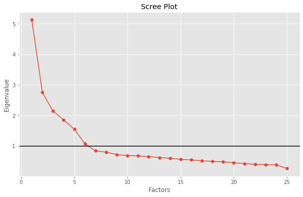

```python
# Create scree plot using matplotlib
plt.scatter(range(1,df.shape[1]+1),ev)
plt.plot(range(1,df.shape[1]+1),ev)
plt.title('Scree Plot')
plt.xlabel('Factors')
plt.ylabel('Eigenvalue')
plt.axhline(y=1,c='k')
```

```python
# Create factor analysis object and perform factor analysis
fa = FactorAnalyzer(n_factors= 6, rotation= 'varimax')
fa.fit(df)
```

```
FactorAnalyzer(bounds=(0.005, 1), impute='median', is_corr_matrix=False,
               method='minres', n_factors=6, rotation='varimax',
               rotation_kwargs={}, use_smc=True)
```

```python
loadings = pd.DataFrame(fa.loadings_)
loadings.columns = ['Factor1','Factor2','Factor3','Factor4','Factor5','Factor6']
loadings.index = df.columns
loadings
```

|  | Factor1 | Factor2 | Factor3 | Factor4 | Factor5 | Factor6 |
| --- | --- | --- | --- | --- | --- | --- |
| A1 | 0.095220 | 0.040783 | 0.048734 | -0.530987 | -0.113057 | 0.161216 |
| A2 | 0.033131 | 0.235538 | 0.133714 | 0.661141 | 0.063734 | -0.006244 |
| A3 | -0.009621 | 0.343008 | 0.121353 | 0.605933 | 0.033990 | 0.160106 |
| A4 | -0.081518 | 0.219717 | 0.235140 | 0.404594 | -0.125338 | 0.086356 |
| A5 | -0.149616 | 0.414458 | 0.106382 | 0.469698 | 0.030977 | 0.236519 |
| C1 | -0.004358 | 0.077248 | 0.554582 | 0.007511 | 0.190124 | 0.095035 |
| C2 | 0.068330 | 0.038370 | 0.674545 | 0.057055 | 0.087593 | 0.152775 |
| C3 | -0.039994 | 0.031867 | 0.551164 | 0.101282 | -0.011338 | 0.008996 |
| C4 | 0.216283 | -0.066241 | -0.638475 | -0.102617 | -0.143846 | 0.318359 |
| C5 | 0.284187 | -0.180812 | -0.544838 | -0.059955 | 0.025837 | 0.132423 |
| E1 | 0.022280 | -0.590451 | 0.053915 | -0.130851 | -0.071205 | 0.156583 |
| E2 | 0.233624 | -0.684578 | -0.088497 | -0.116716 | -0.045561 | 0.115065 |
| E3 | -0.000895 | 0.556774 | 0.103390 | 0.179396 | 0.241180 | 0.267291 |
| E4 | -0.136788 | 0.658395 | 0.113798 | 0.241143 | -0.107808 | 0.158513 |
| E5 | 0.034490 | 0.507535 | 0.309813 | 0.078804 | 0.200821 | 0.008747 |
| N1 | 0.805806 | 0.068011 | -0.051264 | -0.174849 | -0.074977 | -0.096266 |
| N2 | 0.789832 | 0.022958 | -0.037477 | -0.141134 | 0.006726 | -0.139823 |
| N3 | 0.725081 | -0.065687 | -0.059039 | -0.019184 | -0.010664 | 0.062495 |
| N4 | 0.578319 | -0.345072 | -0.162174 | 0.000403 | 0.062916 | 0.147551 |
| N5 | 0.523097 | -0.161675 | -0.025305 | 0.090125 | -0.161892 | 0.120049 |
| O1 | -0.020004 | 0.225339 | 0.133201 | 0.005178 | 0.479477 | 0.218690 |
| O2 | 0.156230 | -0.001982 | -0.086047 | 0.043989 | -0.496640 | 0.134693 |
| O3 | 0.011851 | 0.325954 | 0.093880 | 0.076642 | 0.566128 | 0.210777 |
| O4 | 0.207281 | -0.177746 | -0.005671 | 0.133656 | 0.349227 | 0.178068 |
| O5 | 0.063234 | -0.014221 | -0.047059 | -0.057561 | -0.576743 | 0.135936 |

```python
# Get variance of each factors
var_factor = pd.DataFrame(fa.get_factor_variance())
var_factor.columns = ['Factor1','Factor2','Factor3','Factor4','Factor5','Factor6']
var_factor.index = ['SS Loadings','Proportion Var','Cumulative Var']
var_factor
```

|  | Factor1 | Factor2 | Factor3 | Factor4 | Factor5 | Factor6 |
| --- | --- | --- | --- | --- | --- | --- |
| SS Loadings | 2.726989 | 2.602239 | 2.073471 | 1.713499 | 1.504831 | 0.630297 |
| Proportion Var | 0.109080 | 0.104090 | 0.082939 | 0.068540 | 0.060193 | 0.025212 |
| Cumulative Var | 0.109080 | 0.213169 | 0.296108 | 0.364648 | 0.424841 | 0.450053 |

*Total 45% cumulative Variance explained by the 6 factors.*

*Factor analysis explores large dataset and finds interlinked associations. It reduces the observed variables into a few unobserved variables or identifies the groups of inter-related variables, which help the market researchers to compress the market situations and find the hidden relationship among consumer taste, preference, and cultural influence. Also, It helps in improve questionnaire in for future surveys. Factors make for more natural data interpretation.*

```python
fa.transform(df)
```

```
array([[-0.35050587,  0.03358312, -1.3002851 , -0.51213485, -1.42947498,
        -0.69327464],
       [ 0.08182886,  0.57099878, -0.61213751, -0.20134245, -0.24335182,
        -0.01691128],
       [ 0.56468384,  0.32727718,  0.0830209 , -0.82434468,  0.21016929,
        -0.23617185],
       ...,
       [-0.16606097,  0.70260178,  0.76253293, -1.00085348,  0.94189415,
        -0.42756802],
       [ 0.94217407,  0.70098365,  0.11980022, -2.2071873 ,  0.68202633,
        -0.19390538],
       [-1.53125513, -1.42425818, -0.26009485, -1.46503888,  0.06892041,
        -1.42812815]])
```

#### *Confirmatory Factor Analysis*

```python
from factor_analyzer import ConfirmatoryFactorAnalyzer, ModelSpecificationParser

model_dict = {"F1": ["A1", "A2", "A3", "A4", "A5"], "F2": ["C1", "C2", "C3", "C4", "C5"],
              "F3": ["E1", "E2", "E3", "E4", "E5"], "F4": ["N1", "N2", "N3", "N4", "N5"],
              "F5": ["O1", "O2", "O3", "O4", "O5"]}
model_spec = ModelSpecificationParser.parse_model_specification_from_dict(df, model_dict)

cfa = ConfirmatoryFactorAnalyzer(model_spec, disp=False)
cfa.fit(df)
```

```
ConfirmatoryFactorAnalyzer(bounds=None, disp=False, impute='median',
                           is_cov_matrix=False, max_iter=200, n_obs=2436,
                           specification=<factor_analyzer.confirmatory_factor_analyzer.ModelSpecification object at 0x0000026924065448>,
                           tol=None)
```

```python
cfa.loadings_
```

```
array([[-0.27598972,  0.        ,  0.        ,  0.        ,  0.        ],
       [ 0.82998959,  0.        ,  0.        ,  0.        ,  0.        ],
       [ 1.10290447,  0.        ,  0.        ,  0.        ,  0.        ],
       [ 1.008061  ,  0.        ,  0.        ,  0.        ,  0.        ],
       [ 0.95858751,  0.        ,  0.        ,  0.        ,  0.        ],
       [ 0.        ,  0.91924457,  0.        ,  0.        ,  0.        ],
       [ 0.        ,  0.98452499,  0.        ,  0.        ,  0.        ],
       [ 0.        ,  0.83235904,  0.        ,  0.        ,  0.        ],
       [ 0.        ,  0.17468369,  0.        ,  0.        ,  0.        ],
       [ 0.        ,  0.40262981,  0.        ,  0.        ,  0.        ],
       [ 0.        ,  0.        ,  0.16513458,  0.        ,  0.        ],
       [ 0.        ,  0.        , -0.01304291,  0.        ,  0.        ],
       [ 0.        ,  0.        ,  1.08671011,  0.        ,  0.        ],
       [ 0.        ,  0.        ,  0.95973258,  0.        ,  0.        ],
       [ 0.        ,  0.        ,  0.99368783,  0.        ,  0.        ],
       [ 0.        ,  0.        ,  0.        ,  1.20639214,  0.        ],
       [ 0.        ,  0.        ,  0.        ,  1.14403874,  0.        ],
       [ 0.        ,  0.        ,  0.        ,  1.17783913,  0.        ],
       [ 0.        ,  0.        ,  0.        ,  0.94432461,  0.        ],
       [ 0.        ,  0.        ,  0.        ,  0.88130412,  0.        ],
       [ 0.        ,  0.        ,  0.        ,  0.        ,  0.70846595],
       [ 0.        ,  0.        ,  0.        ,  0.        ,  0.68316337],
       [ 0.        ,  0.        ,  0.        ,  0.        ,  0.70994738],
       [ 0.        ,  0.        ,  0.        ,  0.        ,  0.77406542],
       [ 0.        ,  0.        ,  0.        ,  0.        ,  0.45155168]])
```

```python
cfa.factor_varcovs_
```

```
array([[ 1.        ,  0.15301623,  0.52567689, -0.22664074,  0.21819241],
       [ 0.15301623,  1.        ,  0.22395949,  0.16156083,  0.21364868],
       [ 0.52567689,  0.22395949,  1.        , -0.04199919,  0.28609775],
       [-0.22664074,  0.16156083, -0.04199919,  1.        ,  0.1782286 ],
       [ 0.21819241,  0.21364868,  0.28609775,  0.1782286 ,  1.        ]])
```

```python
pd.DataFrame(cfa.transform(df))
```

|  | 0 | 1 | 2 | 3 | 4 |
| --- | --- | --- | --- | --- | --- |
| 0 | -0.963922 | -1.711128 | -0.610584 | -0.293815 | -0.667938 |
| 1 | -0.423879 | 0.035833 | 0.145775 | 0.316637 | -1.220557 |
| 2 | -0.422884 | 0.075255 | 0.063197 | 0.575743 | -0.315509 |
| 3 | 0.388282 | -0.453128 | -0.166361 | -0.267849 | -1.039846 |
| 4 | -0.943354 | -0.226539 | 0.448940 | -0.062519 | -1.367436 |
| ... | ... | ... | ... | ... | ... |
| 2431 | -1.818776 | 0.331186 | -2.244760 | 1.966076 | -0.129538 |
| 2432 | -0.256207 | -0.463906 | 1.006086 | 0.652364 | 0.567697 |
| 2433 | -0.656237 | 0.336917 | 0.890519 | -0.174554 | -0.050815 |
| 2434 | -1.880012 | 0.837365 | 0.007361 | 1.270260 | -0.114585 |
| 2435 | -2.363743 | 0.019360 | -2.559599 | -1.550902 | -1.713117 |

2436 rows × 5 columns